# Population structure analysis accounting for linkage disequilibrium and SNP coverage

Mar Llaberia-Robledillo & J. Ignacio Lucas Lledó

2025-03-10

## Coverage analysis

I first generate a list of samples for which we have: a BAM file, enough coverage, and metainformation in the `../../data/IDs/Crepido_fish_IDs_all_data_2021Dec.txt` file. Note that some samples do not have enough coverage (listed in `../2023-05-23/VeryBad.txt`, including N044Cx2, N048Cma, N048Cmb, N048Cmc, S031Cmc and T165Cxa).

Previous runs informed of an unexpected positive relationship between depth of coverage and heterozygosity. Suspecting that collapsed duplications could have been biasing the estimates of heterozygosity, we performed a depth analysis and tried to remove over-covered contigs. This is probably unnecessary, and difficult to justify. But I do it anyways.

I use `samtools coverage` to get mean coverage among bases covered at least once per contig. Note that the output of `samtools coverage` is a 9-column text stream with: chromosome name, start position, end position, number of reads, number of bases covered at least once, percentage of covered bases, mean depth of coverage across the whole length, mean base quality and mean mapping quality ([see this link](http://www.htslib.org/doc/samtools-coverage.html)).

```bash
BAM=../2023-05-18/BAM
INFO=../../data/IDs/Crepido_fish_IDs_all_data_2021Dec.txt
BADSAMPLES=../2023-05-23/VeryBad.txt

if [ ! -e samples.txt ]; then
   ls -1 ${BAM}/*.bam | xargs basename -s .bam | \
   grep -v -F -f $BADSAMPLES | \
   grep -f <(tail -n +2 $INFO | cut -f 3 | sed 's/\"//g') > samples.txt
fi

if [ ! -d coverage ]; then mkdir coverage; fi

for SAMPLE in $(cat samples.txt); do
   BAMFILE=${BAM}/$SAMPLE.bam
   if [ ! -e coverage/$SAMPLE.depth ]; then
      samtools coverage $BAMFILE | \
      gawk '(NR > 1){
         if ($5 > 0) {
            print $1 "\t" $7 * ($3 - $2 + 1) / $5
         } else {
            print $1 "\t0"
         }
      }' | sort -k 1,1 > coverage/$SAMPLE.depth
   fi
done
```

```r
samples <- scan('samples.txt', what = 'character', quiet = TRUE)
DEPTH <- matrix(0, nrow = length(readLines(paste0('coverage/', samples[1], '.depth', collapse = ''))),
                ncol = length(samples))
colnames(DEPTH) <- samples
for (s in samples) {
   DEPTH[, s] <- read.table(paste0('coverage/', s, '.depth', collapse = ''))$V2
}
row.names(DEPTH) <- read.table(paste0('coverage/', s, '.depth', collapse = ''))$V1
TotalDepth <- rowSums(DEPTH)
plot(density(TotalDepth, from = 0, to = 600))
abline(v = 100, lty = 2, col = 'orange')
abline(v = 500, lty = 2, col = 'orange')
GoodContigs <- names(TotalDepth[TotalDepth >= 100 & TotalDepth <= 500])
BadContigs  <- names(TotalDepth[TotalDepth < 100 | TotalDepth > 500])
write.table(paste0(GoodContigs, ':'),
            file = 'GoodContigs.txt',
            quote = FALSE,
            row.names = FALSE,
            col.names = FALSE)
write.table(BadContigs,
            file = 'BadContigs.txt',
            quote = FALSE,
            row.names = FALSE,
            col.names = FALSE)
```

[output not shown]

## ANGSD

I will run the following in Garnatxa. The strategy is the following:

1. Get genotype likelihoods in all available sites.
2. Estimate linkage disequilibrium among pairs of sites.
3. Prune the sites to remove high LD pairs.
4. Get genotype likelihoods in selected sites.
5. Run PCangsd and NGSadmix.

For genotype likelihood calculations, we should limit the number of sites also by a minimum coverage threshold and by a minimum number of samples with the required coverage. We did not run preliminary analysis to determine the best thresholds. I need to guess.

```bash
#!/bin/bash
#SBATCH --job-name=angsd1
#SBATCH --output=angsd1.log
#SBATCH --nodes=1
#SBATCH --ntasks=1
#SBATCH --cpus-per-task=8
#SBATCH --mem=10G
#SBATCH --qos=medium
#SBATCH --time=5-00:00:00

module load anaconda
mamba activate bio
module load angsd

cd /scr/joiglu/2024-03-11

BAM=../2023-05-18/BAM
ASM=../2023-05-15/assembly.fasta
EXCLUDE=../2023-05-23/VeryBad.txt
GOODCTG=GoodContigs.txt

if [ ! -e ARCTIC.list ]; then
   ls -1 $BAM/*.bam | \
   grep -E "L|S" | \
   grep -v -F -f $EXCLUDE | \
   grep -v -E 'LR' > ARCTIC.list
fi

if [ ! -d Likes1 ]; then mkdir Likes1; fi
MININD=60
MINDEPTHIND=2
  if [ ! -e Likes1/ARCTIC.beagle.gz ]; then
    angsd -bam ARCTIC.list \
          -ref $ASM \
          -rf $GOODCTG \
          -out Likes1/ARCTIC \
          -only_proper_pairs 0 \
          -baq 1 \
          -setMinDepthInd $MINDEPTHIND \
          -minInd $MININD \
          -GL 1 \
          -doGlf 2 \
          -doIBS 1 \
          -doCounts 1 \
          -doCov 1 \
          -makeMatrix 1 \
          -doMajorMinor 1 \
          -doMaf 1 \
          -SNP_pval 1e-6 \
          -minMapQ 30 \
          -minQ 20 \
          -minMaf 0.05 \
          -nThreads 8 \
          1> Likes1/ARCTIC.angsd.log \
          2> Likes1/ARCTIC.angsd.err
fi
```

```bash
#!/bin/bash
#SBATCH --job-name=sites
#SBATCH --output=sites.log
#SBATCH --nodes=1
#SBATCH --ntasks=1
#SBATCH --cpus-per-task=8
#SBATCH --mem=10G
#SBATCH --qos=medium
#SBATCH --time=5-00:00:00

module load anaconda
mamba activate bio
module load angsd

cd /scr/joiglu/2024-03-11

ASM=../2023-05-15/assembly.fasta
MININD=60
MINDEPTHIND=2

if [ ! -d Likes2 ]; then mkdir Likes2; fi
if [ ! -d Sites ]; then mkdir Sites; fi

if [ ! -e Likes2/ARCTIC.beagle.gz ]; then
   if [ ! -e Sites/ARCTIC_snp.sites ]; then
      if [ ! -e Sites/ARCTIC_snp.ld ]; then
         gunzip -c Likes1/ARCTIC.mafs.gz | \
         cut -f 1,2 | \
         tail -n +2 > Sites/posFile.txt
         ngsLD --geno Likes1/ARCTIC.beagle.gz \
               --probs \
               --pos Sites/posFile.txt \
               --n_ind $(cat ARCTIC.list | wc -l) \
               --n_sites $(cat Sites/posFile.txt | wc -l) \
               --n_threads 8 \
               --out Sites/ARCTIC_snp.ld \
               1> Sites/ngsLD.ARCTIC.log \
               2> Sites/ngsLD.ARCTIC.err
         head -n 1 Sites/ARCTIC_snp.ld > Sites/ARCTIC_snp.ld.header
         tail -n +2 Sites/ARCTIC_snp.ld > z
         mv z Sites/ARCTIC_snp.ld
         rm Sites/posFile.txt
      fi
      ~/software/NGSTOOLS/ngsLD/scripts/prune_ngsLD.py \
                     --input Sites/ARCTIC_snp.ld \
                     --output Sites/ARCTIC_snp.sites \
                     --max_dist 100000 \
                     --min_weight 0.85
   fi
   if [ ! -e Sites/ARCTIC_snp.sites.bin ]; then
      sed -i 's/:/\t/' Sites/ARCTIC_snp.sites
      angsd sites index Sites/ARCTIC_snp.sites 2> Sites/ARCTIC_snp.sites.log
   fi
   angsd -bam ARCTIC.list \
         -ref $ASM \
         -sites Sites/ARCTIC_snp.sites \
         -out Likes2/ARCTIC \
         -only_proper_pairs 1 \
         -baq 1 \
         -setMinDepthInd $MINDEPTHIND \
         -minInd $MININD \
         -GL 1 \
         -doGlf 2 \
         -doIBS 1 \
         -doCounts 1 \
         -doCov 1 \
         -makeMatrix 1 \
         -doMajorMinor 1 \
         -doMaf 1 \
         -SNP_pval 1.0e-6 \
         -minMapQ 30 \
         -minQ 20 \
         -minMaf 0.05 \
         -nThreads 8 \
         1> Likes2/ARCTIC.angsd.log \
         2> Likes2/ARCTIC.angsd.err
fi
```

```bash
#!/bin/bash
#SBATCH --job-name=popstruc
#SBATCH --output=popstruc.log
#SBATCH --nodes=1
#SBATCH --ntasks=1
#SBATCH --cpus-per-task=8
#SBATCH --mem=10G
#SBATCH --qos=medium
#SBATCH --time=5-00:00:00

module load anaconda
mamba activate bio
module load angsd

cd /scr/joiglu/crepi/results/2024-03-11

if [ ! -d PCangsd ]; then mkdir PCangsd; fi
if [ ! -e PCangsd/ARCTIC.cov ]; then
   pcangsd --beagle Likes2/ARCTIC.beagle.gz \
           --out PCangsd/ARCTIC \
           --threads 8 \
           1> PCangsd/ARCTIC.stdout \
           2> PCangsd/ARCTIC.stderr
fi

if [ ! -d NGSadmix ]; then mkdir NGSadmix; fi
for K in 2 3 4 5; do
   if [ ! -e NGSadmix/ARCTIC.K${K}.qopt ]; then
      ~/software/NGSTOOLS/angsd/misc/NGSadmix \
               -likes Likes2/ARCTIC.beagle.gz \
               -K $K \
               -P 8 \
               -outfiles NGSadmix/ARCTIC.K${K} \
               -minMaf 0.05 \
               -maxiter 8000 \
               1> NGSadmix/ARCTIC.NGSadmix.K${K}.log \
               2> NGSadmix/ARCTIC.NGSadmix.K${K}.err
   fi
done

for K in 2 3 4 5; do
   if [ ! -e NGSadmix/ARCTIC.K${K}.eval ]; then
      evalAdmix -beagle Likes2/ARCTIC.beagle.gz \
                -fname NGSadmix/ARCTIC.K${K}.fopt.gz \
                -qname NGSadmix/ARCTIC.K${K}.qopt \
                -o NGSadmix/ARCTIC.K${K}.eval &
   fi
done
```

## PCangsd results

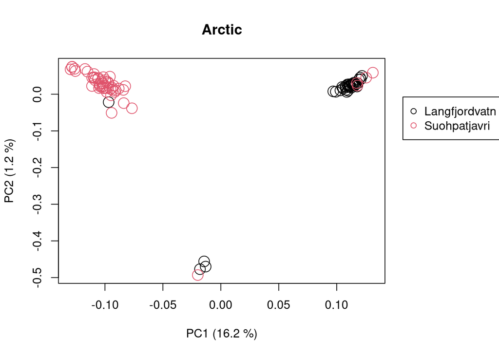

```r
# It seems safer to rely on the metadata than on the sample's initial to assign lakes.
MetaData <- read.table('../../data/IDs/Crepido_fish_IDs_all_data_2021Dec.txt')
row.names(MetaData) <- MetaData$P_code
IndNames <- gsub('(../2023-05-18/BAM/|.bam)', '',
                 scan('ARCTIC.list', what = 'character', quiet = TRUE))
Lake <- factor(MetaData[IndNames, 'Lake'],
               levels = c('Langfjordvatn', 'Suopatjavri'))
cov <- as.matrix(read.table('PCangsd/ARCTIC.cov'))
e   <- eigen(cov)
layout(matrix(1:2, ncol = 2), width = c(4, 1), height = c(1, 1))
par(mar = c(5.1, 4.1, 4.1, 1))
plot(e$vectors[, c(1, 2)], col = Lake, cex = 2,
     xlab = sprintf('PC1 (%.1f %%)', 100 * e$values[1] / sum(e$values)),
     ylab = sprintf('PC2 (%.1f %%)', 100 * e$values[2] / sum(e$values)),
     main = 'Arctic')
par(mar = c(0, 0, 4.1, 0))
plot(c(0, 1), c(0, 1), type = 'n', axes = FALSE, xlab = '', ylab = '')
legend(0, 0.9, c('Langfjordvatn', 'Suohpatjavri'),
       col = 1:2, pch = 1, cex = 1)
```

## NGSadmix results

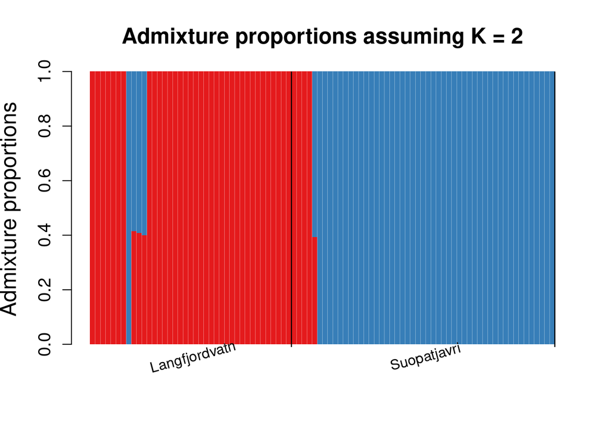

```r
source('/data/joiglu/bin/evalAdmix/visFuns.R')
IndNames <- gsub('(../2023-05-18/BAM/|.bam)', '',
                 scan('ARCTIC.list', what = 'character', quiet = TRUE))
Lake <- MetaData[IndNames, 'Lake']
QK2 <- read.table('NGSadmix/ARCTIC.K2.qopt')
QK3 <- read.table('NGSadmix/ARCTIC.K3.qopt')
QK4 <- read.table('NGSadmix/ARCTIC.K4.qopt')
QK5 <- read.table('NGSadmix/ARCTIC.K5.qopt')

ord <- orderInds(pop = Lake, q = QK3,
                 popord = c('Langfjordvatn', 'Suopatjavri'))
plotAdmix(QK2, pop = Lake, ord = ord, rotatelab = 15)
```

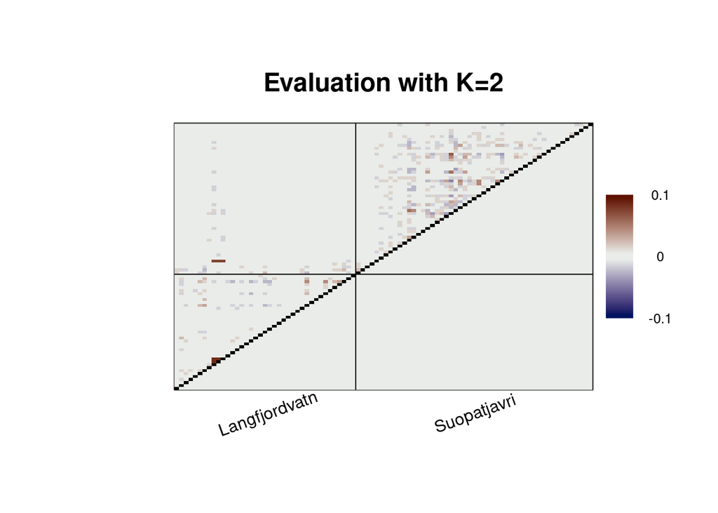

```r
r <- as.matrix(read.table('NGSadmix/ARCTIC.K2.eval'))
plotCorRes(cor_mat = r, pop = Lake, ord = ord,
           title = 'Evaluation with K=2', min_z = -0.1,
           max_z = 0.1, rotatelabpop = 20, cex.lab = 1,
           pop_labels = c(FALSE, TRUE), cex.legend = 0.8)
```

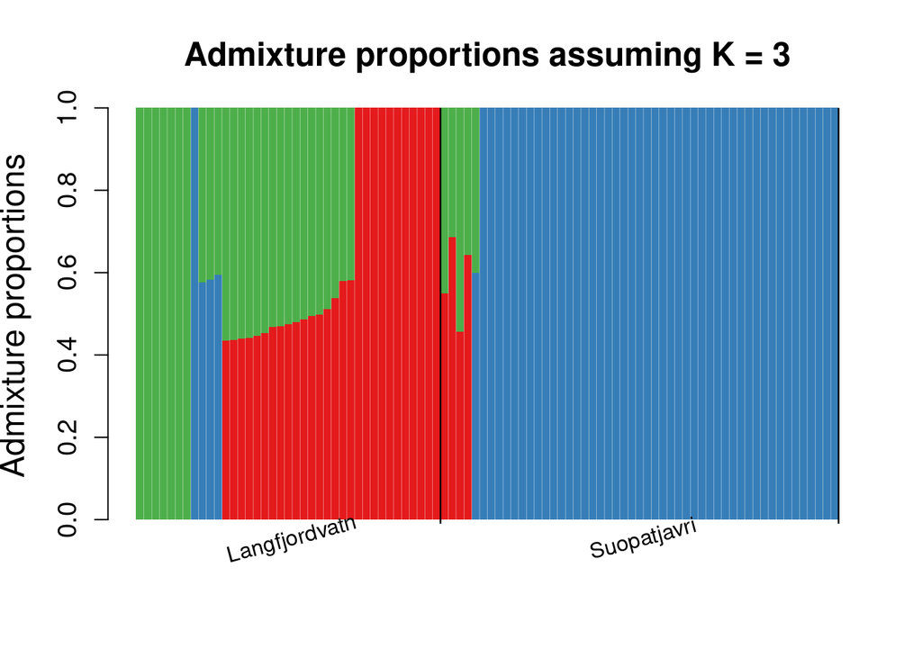

```r
plotAdmix(QK3, pop = Lake, ord = ord, rotatelab = 15)
```

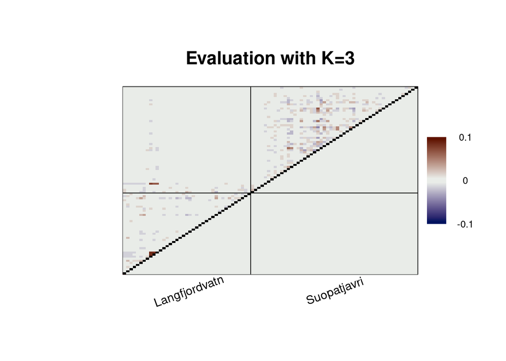

```r
r <- as.matrix(read.table('NGSadmix/ARCTIC.K3.eval'))
plotCorRes(cor_mat = r, pop = Lake, ord = ord,
           title = 'Evaluation with K=3', min_z = -0.1,
           max_z = 0.1, rotatelabpop = 20, cex.lab = 1,
           pop_labels = c(FALSE, TRUE), cex.legend = 0.8)
```

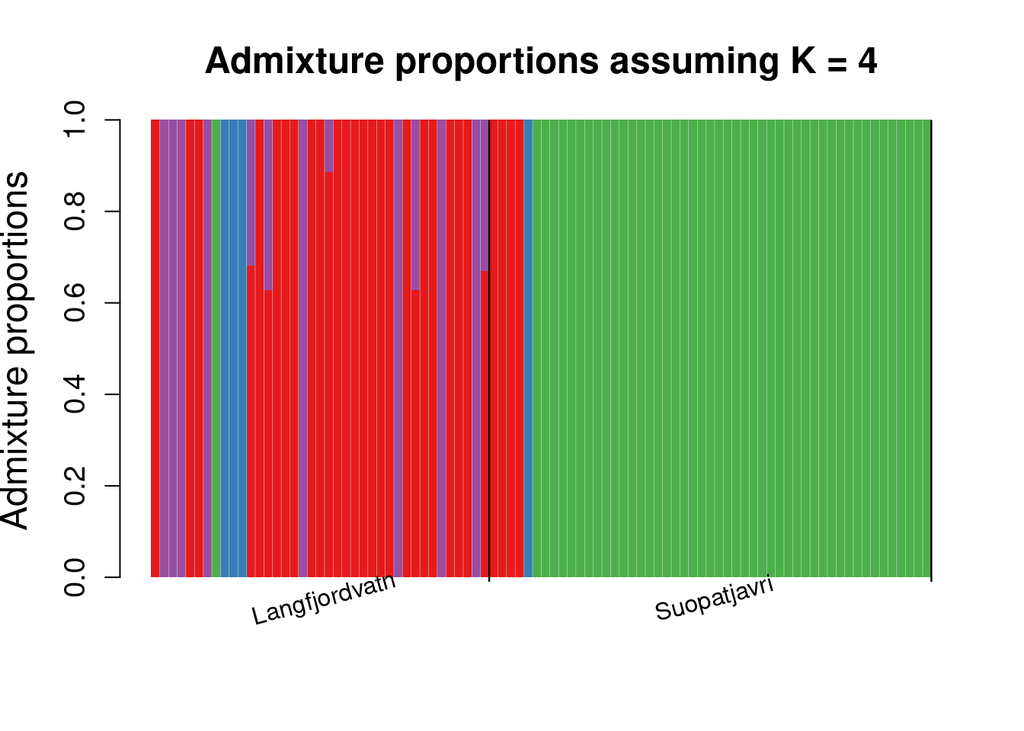

```r
plotAdmix(QK4, pop = Lake, ord = ord, rotatelab = 15)
```

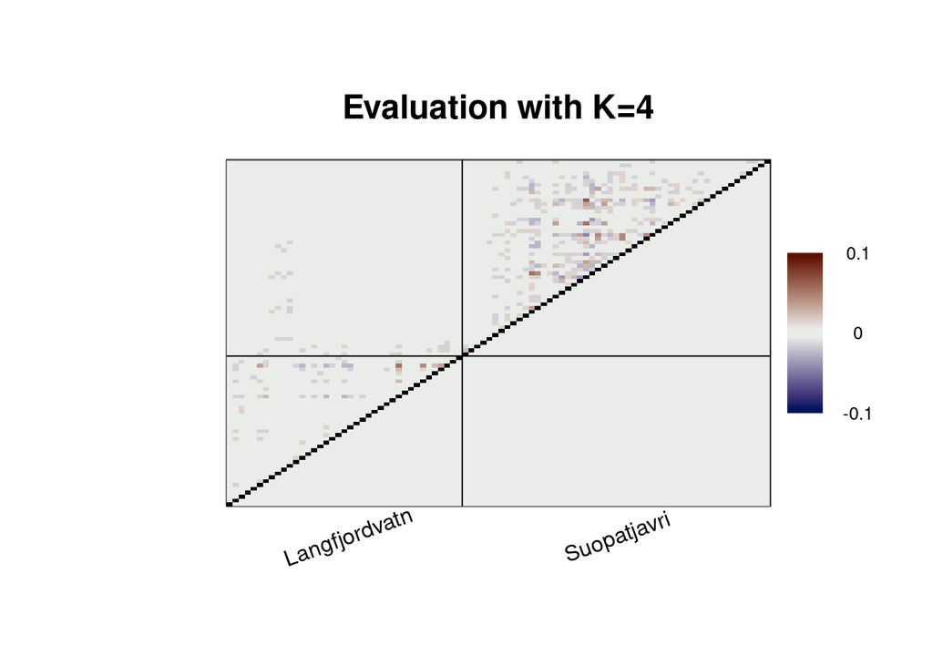

```r
r <- as.matrix(read.table('NGSadmix/ARCTIC.K4.eval'))
plotCorRes(cor_mat = r, pop = Lake, ord = ord,
           title = 'Evaluation with K=4', min_z = -0.1,
           max_z = 0.1, rotatelabpop = 20, cex.lab = 1,
           pop_labels = c(FALSE, TRUE), cex.legend = 0.8)
```

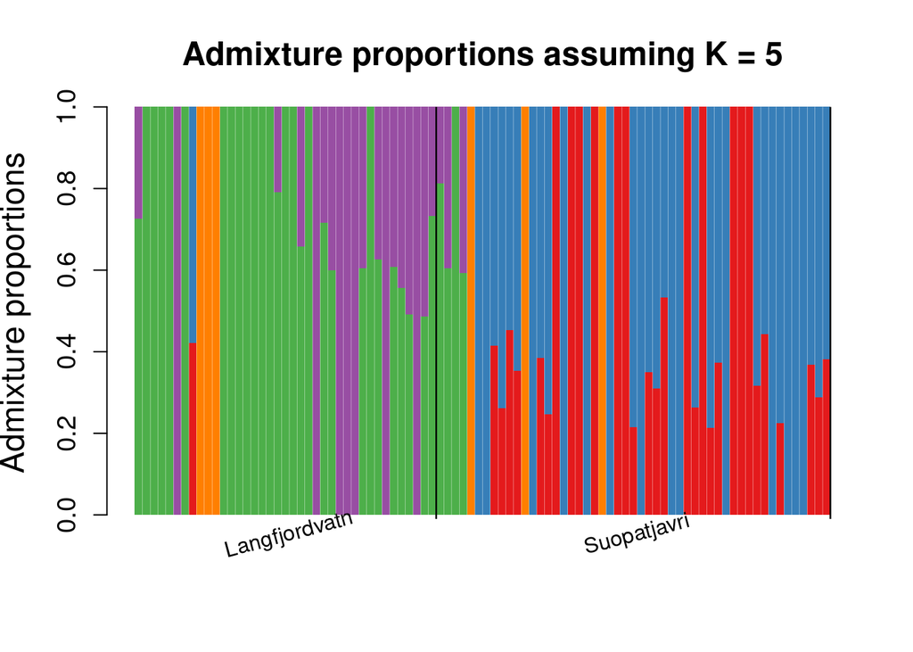

```r
plotAdmix(QK5, pop = Lake, ord = ord, rotatelab = 15)
```

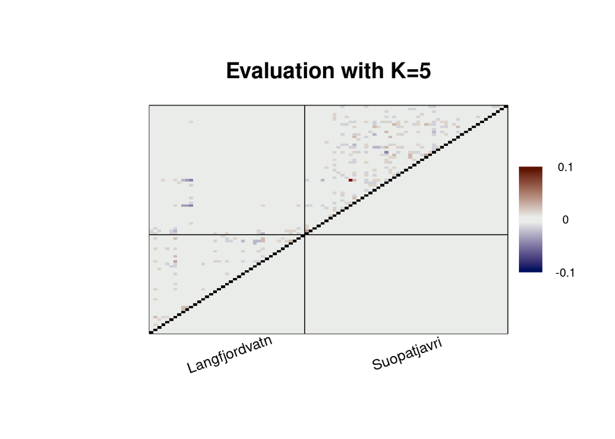

```r
r <- as.matrix(read.table('NGSadmix/ARCTIC.K5.eval'))
plotCorRes(cor_mat = r, pop = Lake, ord = ord,
           title = 'Evaluation with K=5', min_z = -0.1,
           max_z = 0.1, rotatelabpop = 20, cex.lab = 1,
           pop_labels = c(FALSE, TRUE), cex.legend = 0.8)
```